# Chapter 3: Data Visualisation

# 3.9 Coordinate systems

## 3.9.1 Exercises

1. Turn a stacked bar chart into a pie chart using `coord_polar()`.

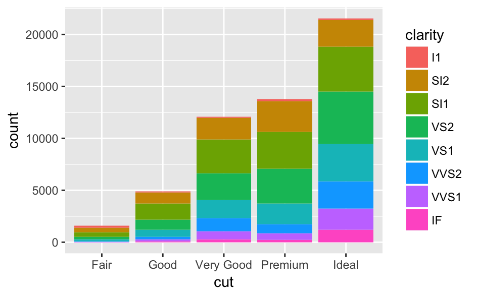

```r
ggplot(data = diamonds) +
  geom_bar(mapping = aes(x = cut, fill = clarity))
```

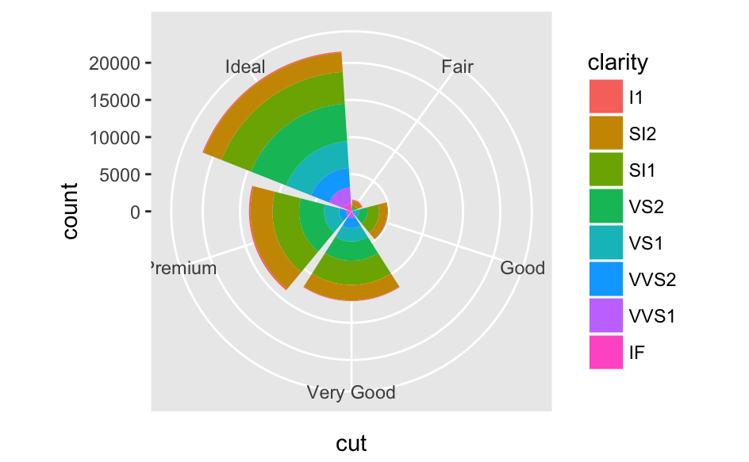

```r
ggplot(data = diamonds) +
  geom_bar(mapping = aes(x = cut, fill = clarity)) +
  coord_polar()
```

2. What does `labs()` do? Read the documentation.

```r
?labs
```

**`labs()` modifies chart labels, including title, subtitle, caption, axis and legend text.**

3. What’s the difference between `coord_quickmap()` and `coord_map()`?

```r
?coord_map
```

**Both functions set the projection or aspect ratio for maps, but `coord_map` does full computations and can use any of the available map projections, whereas `coord_quickmap` uses an estimation approach based on the mercator projection that requires much less computation (i.e., is faster) while producing a reasonable approximation in most circumstances.**

4. What does the plot below tell you about the relationship between city and highway mpg? Why is `coord_fixed()` important? What does `geom_abline()` do?

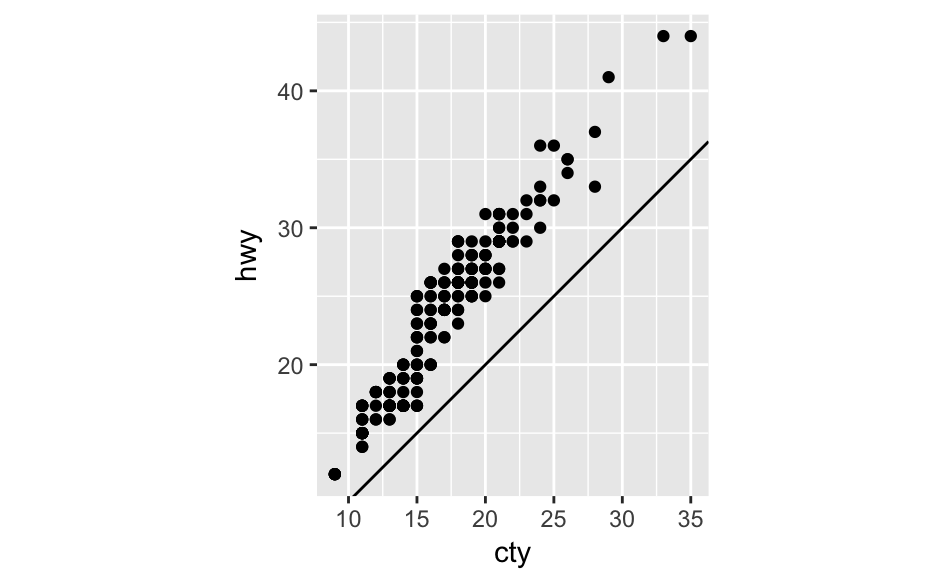

```r
ggplot(data = mpg, mapping = aes(x = cty, y = hwy)) +
  geom_point() +
  geom_abline() +
  coord_fixed()
```

**The plot shows a strong positive correlation between city and highway mpg, with highway mpg always higher than city mpg for all vehicles in the dataset.**

**`coord_fixed()` is important becase it ensures the plot’s axes have a 1:1 aspect ratio – see below for what the plot looks like without it. `geom_abline()` plots a sloping line which, because no parameters were set, has `intercept = 0` and `slope = 1`, which allows comparison of the scatterplot to a line indicating a direct correspondence between city and highway mpg.**

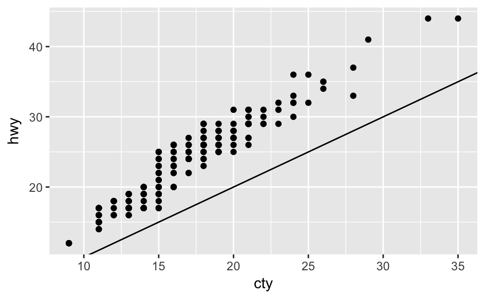

```r
ggplot(data = mpg, mapping = aes(x = cty, y = hwy)) +
  geom_point() +
  geom_abline()
```